# Loan Data from Propser by Tan Kwok Wee

## Credit Grade/ProsperRating..Alpha. vs BorrowerRate

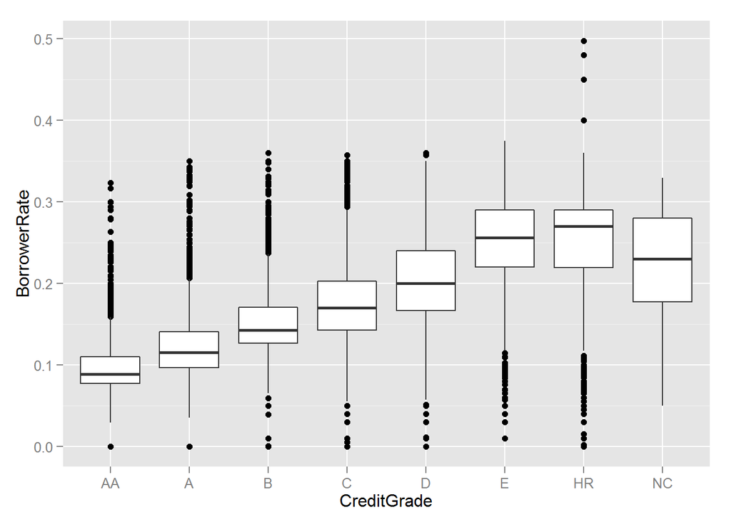

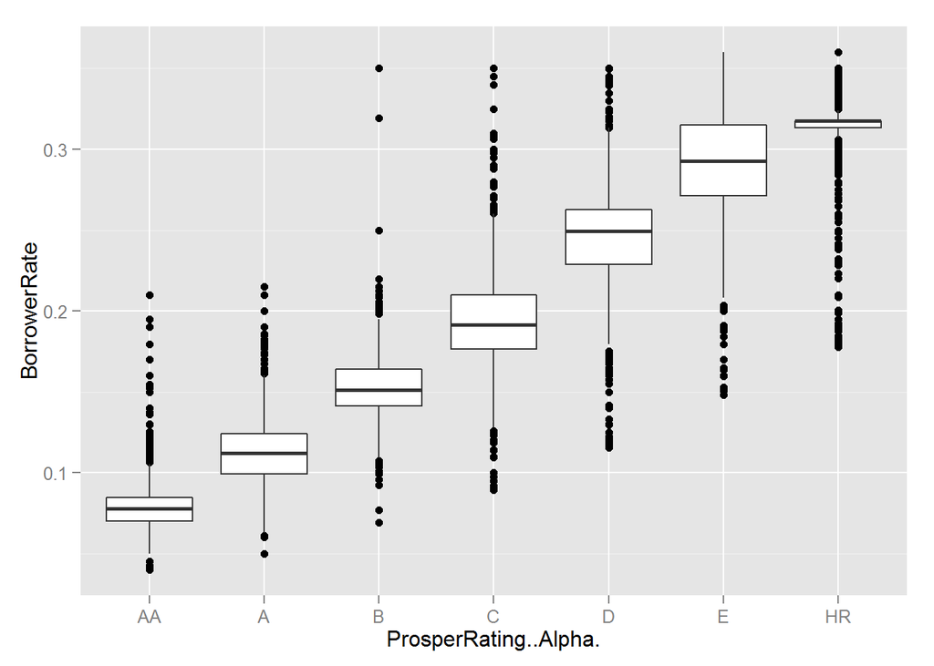

by plotting GreditGrade versus Borrower Rate we can see that borrowers with lower credit grade paid more interest as compared with borrowers with higher credit grade. for borrowers with lower creditgrade the Borrower Rates varies wider as compared with those having a better creditgrade

## Employment Status vs BorrowerRate

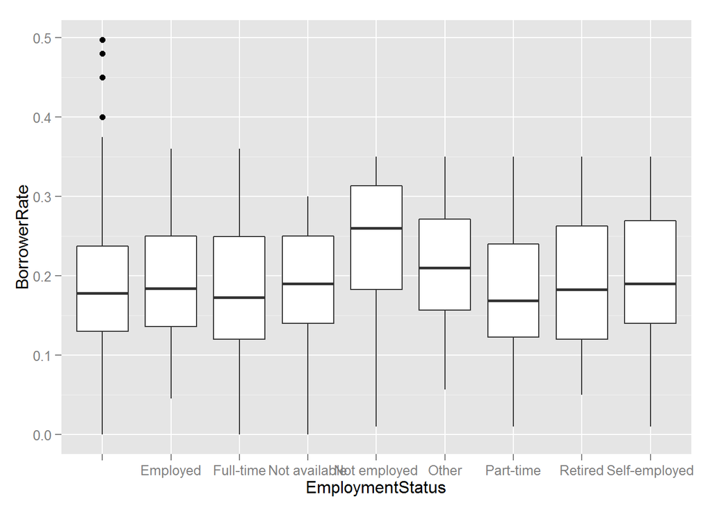

We can see that borrowers that are “Not Employed” and “Other” have a higher borrower rate ( greater than 20%) as compared with other employment status.

# Bivariate Analysis

### Talk about some of the relationships you observed in this part of the investigation. How did the feature(s) of interest vary with other features in the dataset?

we can see as loan amounts get larger the term of loan stablizes around 36 months.

we can see that the range of loan amounts increases after 2011

If we see the boxplots of credit grade verus Loan Origination Amount, we can see that highest credit Grade obtained more loan amounts at lower borrower rate.

There are certain outliers obtaining loan amounts of 20,000 or more despite having a bad credit rating.

We can see that people that are employed requested for bigger loan amounts as compared with other employment status.

There is a linear relationship between borrower rate and lender yield, increase in borrower rate corresponds with an increase with lender yield.

we can also see that borrowers with the Best credit grade enjoy lowest borrower rate.

### Did you observe any interesting relationships between the other features (not the main feature(s) of interest)?

In the plot of BorrowerState vs CreditGrade, we can observe that people in NY has better credit grade than the rest of the states ( CA, FL, IL, TX)

### What was the strongest relationship you found?

the strongest relationships i found is between borrower yield and lender rate they have the correlation of 99.9%

# Multivariate Plots Section

Let us check the distirbution of loan amounts by Credit Grade and borrower State for (CA, TX, NY, IL, FL)

## Borrower State ( CA, TX, NY, IL, FL ) and CreditGrade and Percentage of Loan Amount

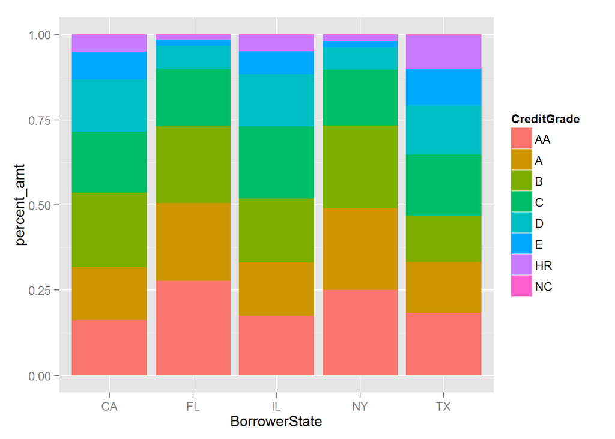

We can see that in terms of credit grade and loan amount percentage Florida and New York have almost the same distribution.

Next let us check the borrower Rate vs Credit Grade by IncomeRange

## Borrower Rate/Prosper Rating Alpha vs Credit Grade/ProsperRating..Alpha. by Income Range

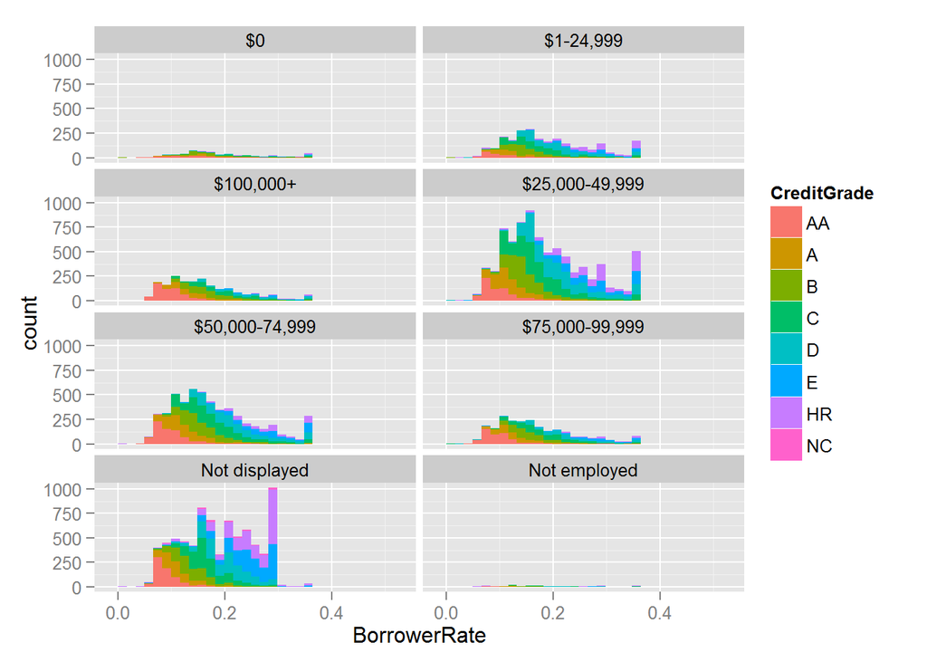

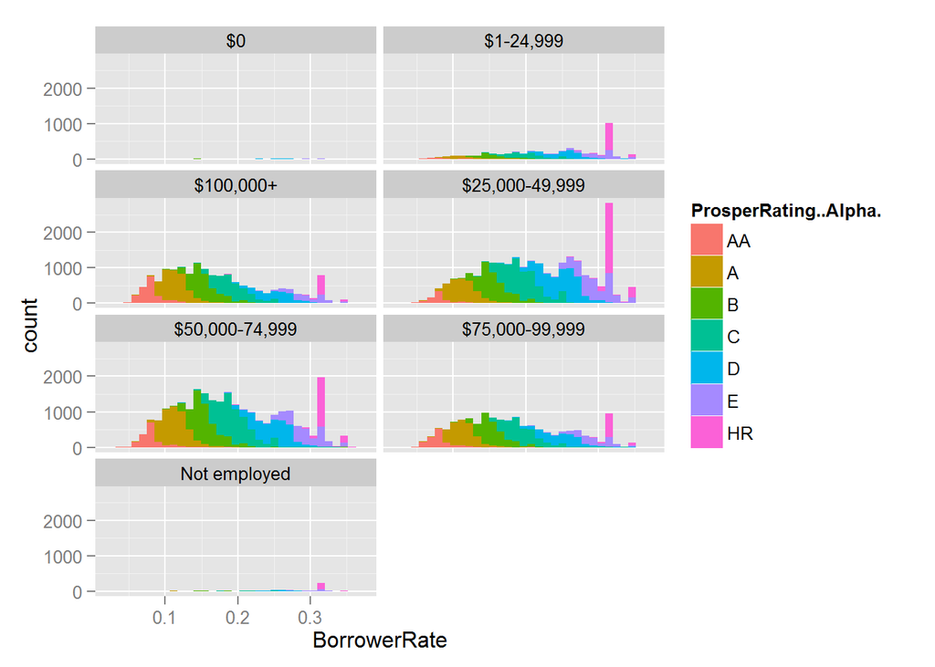

we can see the similar patterns of distribution of borrwing rates across all income range which varies by the CreditGrade/ProsperRating..Alpha.. The borrowers having lower creditgrade or prosperrating..alpha. (D,E,HR) are having interest rates greater than 0.2

## Employment Status vs Borrower Rate by Credit Grade/ProsperRating..Alpha.

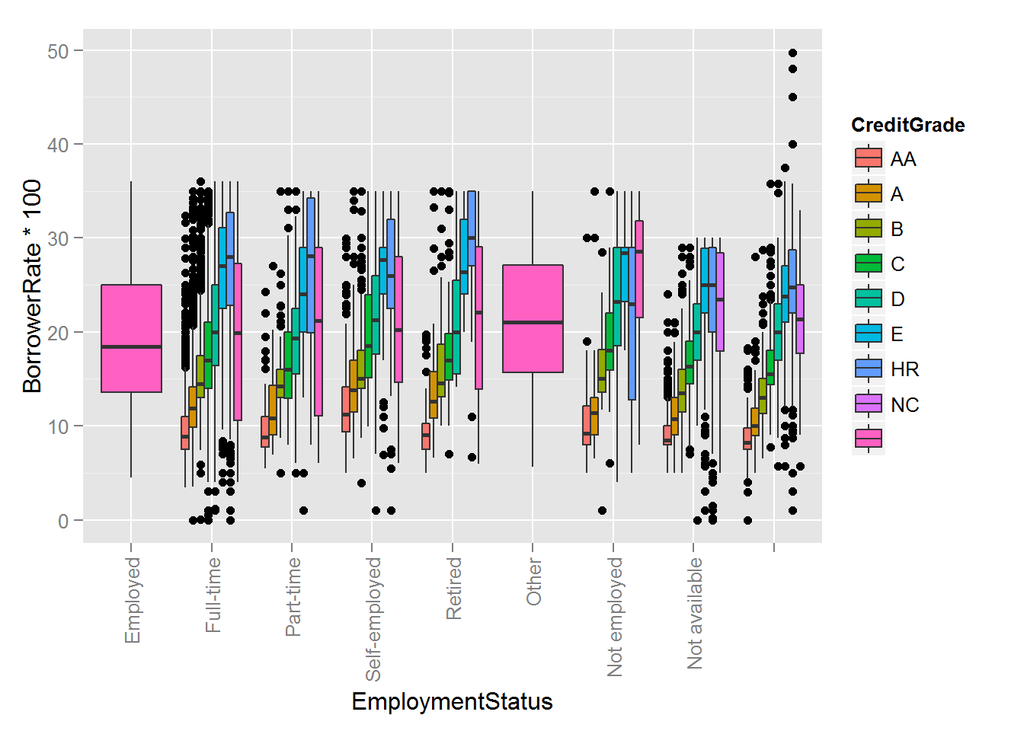

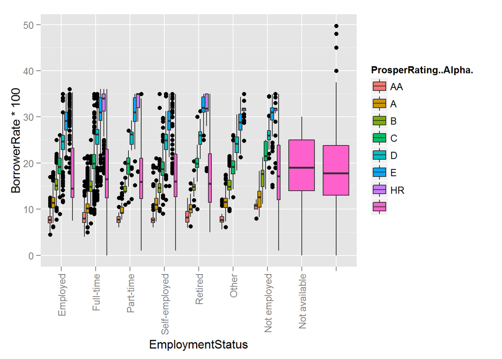

Next, let’s understand loss by employment status grouped by CreditGrade/Proper Rating Alpha

## Employment Status vs Loss by Credit Grade

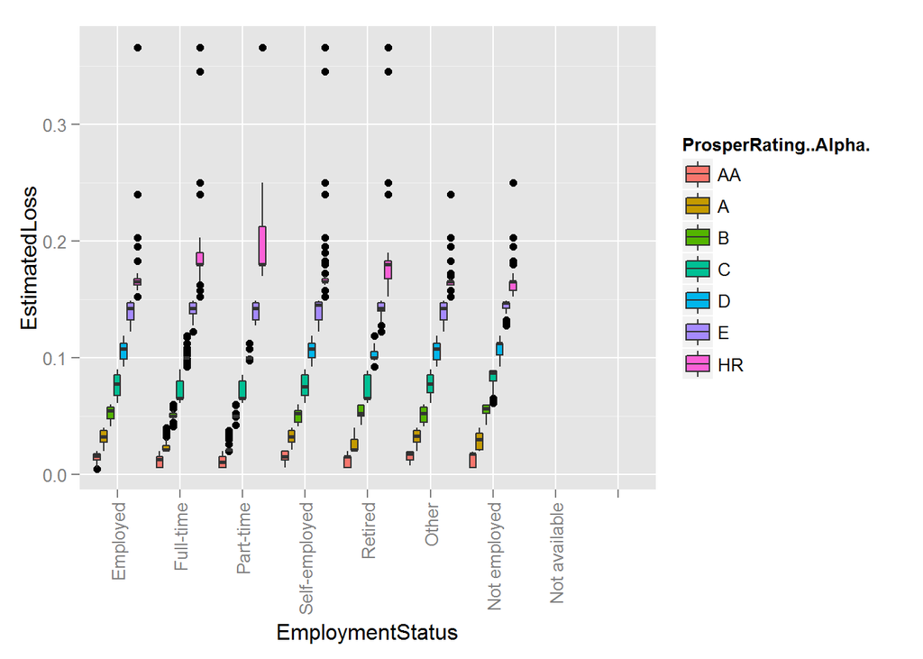

We can see that the estimated loss for different employement status by credit grade have almost the same variation and borrowers with lower credit grade will have a higher estimated loss percentage. lets check if higher loan amounts will mean higher estimated loss?

## Loan Amount vs Estimated Loss by Proper Rating .. Alpha

```
##        (Intercept) LoanOriginalAmount
##      10.9346917298      -0.0003197143
```

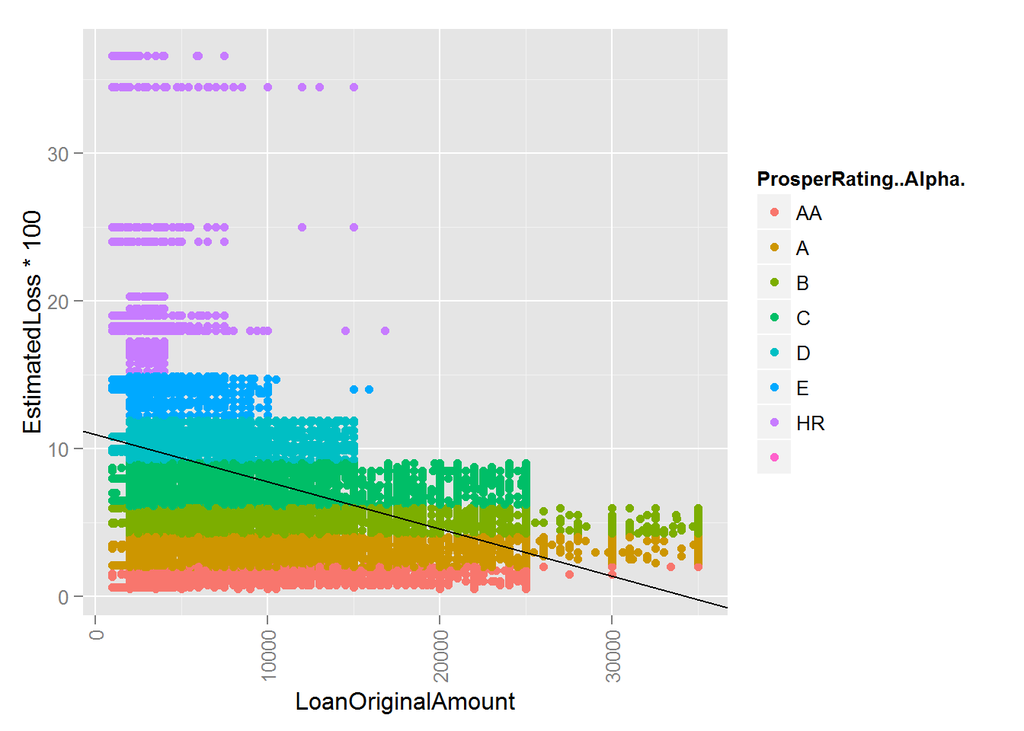

there is a negative correlation between esitmated loss vs loan original amount. let’s check estimated loss with debt to income ratio

## Debt to Income Ratio vs Estimated Loss by Proper Rating .. Alpha

```
##       (Intercept) DebtToIncomeRatio
##          7.388626          1.820000
```

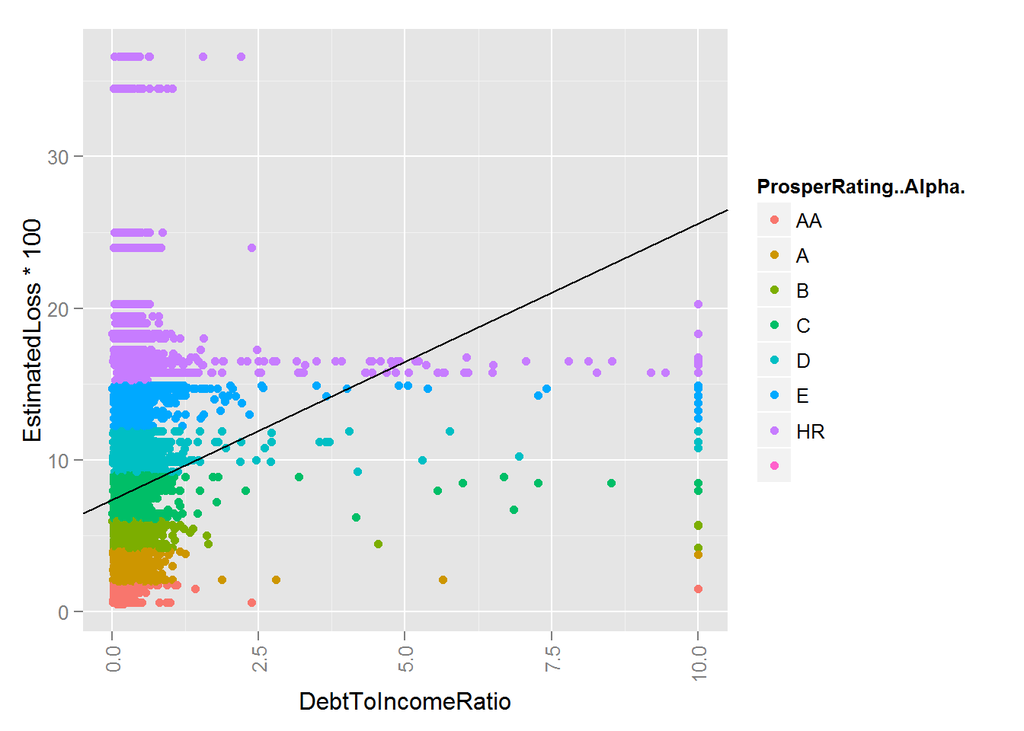

We can see a positive correlation between Estimated loss vs Debt to Income Ratio. We also can see borrowers with poor Prosper Rating.. Alpha (D, E, HR) has higher estimated loss. There are more occurences when debt to income ratio is greater than 2.0.

## Linear Model - Borrower Rates

```
##
## Call:
## lm(formula = BorrowerRate ~ ProsperScore + TotalProsperLoans +
##     ProsperRating..Alpha., data = ld)
##
## Residuals:
##       Min        1Q    Median        3Q       Max
## -0.142221 -0.012422 -0.001358  0.013110  0.160230
##
## Coefficients:
##                           Estimate Std. Error t value Pr(>|t|)
## (Intercept)              9.826e-02  1.152e-03  85.273  < 2e-16 ***
## ProsperScore            -2.170e-03  9.289e-05 -23.361  < 2e-16 ***
## TotalProsperLoans       -7.526e-04  2.037e-04  -3.694 0.000221 ***
## ProsperRating..Alpha.A   3.344e-02  7.143e-04  46.813  < 2e-16 ***
## ProsperRating..Alpha.B   7.145e-02  7.870e-04  90.789  < 2e-16 ***
## ProsperRating..Alpha.C   1.118e-01  8.391e-04 133.225  < 2e-16 ***
## ProsperRating..Alpha.D   1.562e-01  8.801e-04 177.469  < 2e-16 ***
## ProsperRating..Alpha.E   2.095e-01  9.759e-04 214.695  < 2e-16 ***
## ProsperRating..Alpha.HR  2.252e-01  1.084e-03 207.792  < 2e-16 ***
## ---
## Signif. codes:  0 '***' 0.001 '**' 0.01 '*' 0.05 '.' 0.1 ' ' 1
##
## Residual standard error: 0.02259 on 19788 degrees of freedom
##   (94140 observations deleted due to missingness)
## Multiple R-squared:  0.9159, Adjusted R-squared:  0.9158
## F-statistic: 2.692e+04 on 8 and 19788 DF,  p-value: < 2.2e-16
```

We can see that prosper score, total prosper loans and propserrating.. alpha are the independent variables that are able to explain 91.59% of the variation in borrower’s rate

## Linear Model - Estimated Loss

```
##
## Call:
## lm(formula = EstimatedLoss ~ ProsperScore + TotalProsperLoans +
##     ProsperRating..Alpha., data = ld)
##
## Residuals:
##       Min        1Q    Median        3Q       Max
## -0.042837 -0.006834 -0.001083  0.005413  0.170029
##
## Coefficients:
##                           Estimate Std. Error t value Pr(>|t|)
## (Intercept)              2.480e-02  7.225e-04  34.329   <2e-16 ***
## ProsperScore            -1.168e-03  5.824e-05 -20.057   <2e-16 ***
## TotalProsperLoans        1.335e-04  1.277e-04   1.045    0.296
## ProsperRating..Alpha.A   1.321e-02  4.479e-04  29.491   <2e-16 ***
## ProsperRating..Alpha.B   3.207e-02  4.934e-04  65.000   <2e-16 ***
## ProsperRating..Alpha.C   5.361e-02  5.261e-04 101.899   <2e-16 ***
## ProsperRating..Alpha.D   8.189e-02  5.518e-04 148.401   <2e-16 ***
## ProsperRating..Alpha.E   1.183e-01  6.119e-04 193.356   <2e-16 ***
## ProsperRating..Alpha.HR  1.722e-01  6.795e-04 253.430   <2e-16 ***
## ---
## Signif. codes:  0 '***' 0.001 '**' 0.01 '*' 0.05 '.' 0.1 ' ' 1
##
## Residual standard error: 0.01416 on 19788 degrees of freedom
##   (94140 observations deleted due to missingness)
## Multiple R-squared:  0.9238, Adjusted R-squared:  0.9238
## F-statistic: 2.999e+04 on 8 and 19788 DF,  p-value: < 2.2e-16
```

Similarly, prosper score, total prosper loans and propserrating.. alpha are the independent variables that are able to explain 92.38% of the variation in estimated loss.

## Linear Model - Lender Yield

```
##
## Call:
## lm(formula = LenderYield ~ ProsperScore + TotalProsperLoans +
##     ProsperRating..Alpha., data = ld)
##
## Residuals:
##       Min        1Q    Median        3Q       Max
## -0.142202 -0.012417 -0.001348  0.013111  0.160253
##
## Coefficients:
##                           Estimate Std. Error t value Pr(>|t|)
## (Intercept)              8.830e-02  1.152e-03   76.65  < 2e-16 ***
## ProsperScore            -2.174e-03  9.286e-05  -23.41  < 2e-16 ***
## TotalProsperLoans       -7.494e-04  2.036e-04   -3.68 0.000234 ***
## ProsperRating..Alpha.A   3.343e-02  7.141e-04   46.82  < 2e-16 ***
## ProsperRating..Alpha.B   7.144e-02  7.868e-04   90.80  < 2e-16 ***
## ProsperRating..Alpha.C   1.118e-01  8.388e-04  133.24  < 2e-16 ***
## ProsperRating..Alpha.D   1.562e-01  8.798e-04  177.50  < 2e-16 ***
## ProsperRating..Alpha.E   2.095e-01  9.756e-04  214.73  < 2e-16 ***
## ProsperRating..Alpha.HR  2.251e-01  1.083e-03  207.81  < 2e-16 ***
## ---
## Signif. codes:  0 '***' 0.001 '**' 0.01 '*' 0.05 '.' 0.1 ' ' 1
##
## Residual standard error: 0.02258 on 19788 degrees of freedom
##   (94140 observations deleted due to missingness)
## Multiple R-squared:  0.9159, Adjusted R-squared:  0.9159
## F-statistic: 2.694e+04 on 8 and 19788 DF,  p-value: < 2.2e-16
```

Similarly, prosper score, total prosper loans and propserrating.. alpha are the independent variables that are able to explain 91.59% of the variation in lender yield.

# Multivariate Analysis

### Talk about some of the relationships you observed in this part of the investigation. Were there features that strengthened each other in terms of looking at your feature(s) of interest?

We can see a positive correlation between Estimated loss vs Debt to Income Ratio. We also can see borrowers with poor Prosper Rating.. Alpha (D, E, HR) has higher estimated loss. There are more occurences when debt to income ratio is greater than 2.0.

### Were there any interesting or surprising interactions between features?

we can observe that there are people without stated monthly income with loans greater than 20,000

There is a negative correlation between esitmated loss vs loan original amount. My initial impression that greater loan amounts will affect estimated loss percentage.

### OPTIONAL: Did you create any models with your dataset? Discuss the strengths and limitations of your model.

yes, i had created 3 linear models on Borrower Rates, Estimated Loss and Lender Yield.

I had used multiple linear regression model to predict dependant variable ( BorrowerRate, EstimatedLoss) and using Adjusted R-Square to evaluate the model.

The model is simple to use and understand, but linear regression is unable to predict outliers and unable to establish causation.

# Final Plots and Summary

### Plot One

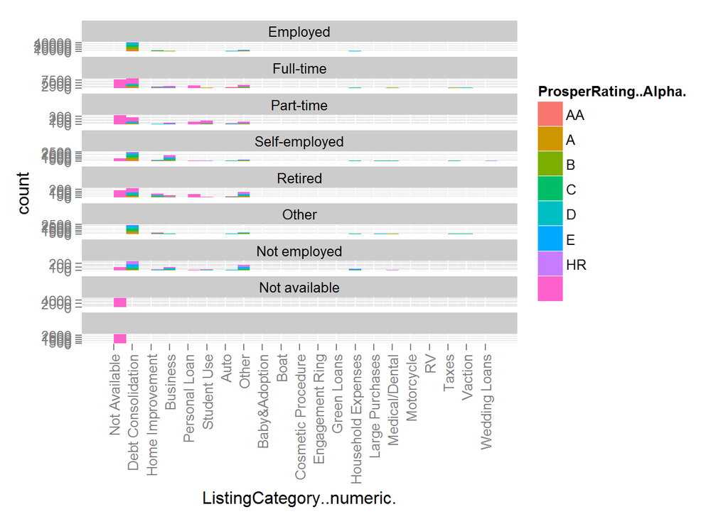

### Description One

Debt Consolidation is primary reason after “NA” for borrowing accross most employment status.

From the plot, we can observe the following * borrowing for “Business”" purpose has more occurences in “self employed” group then the rest * borrowing for “Student Use” more common in “Part-time” group * borrowing for “Home improvement” is more common in “retired” group

### Plot Two

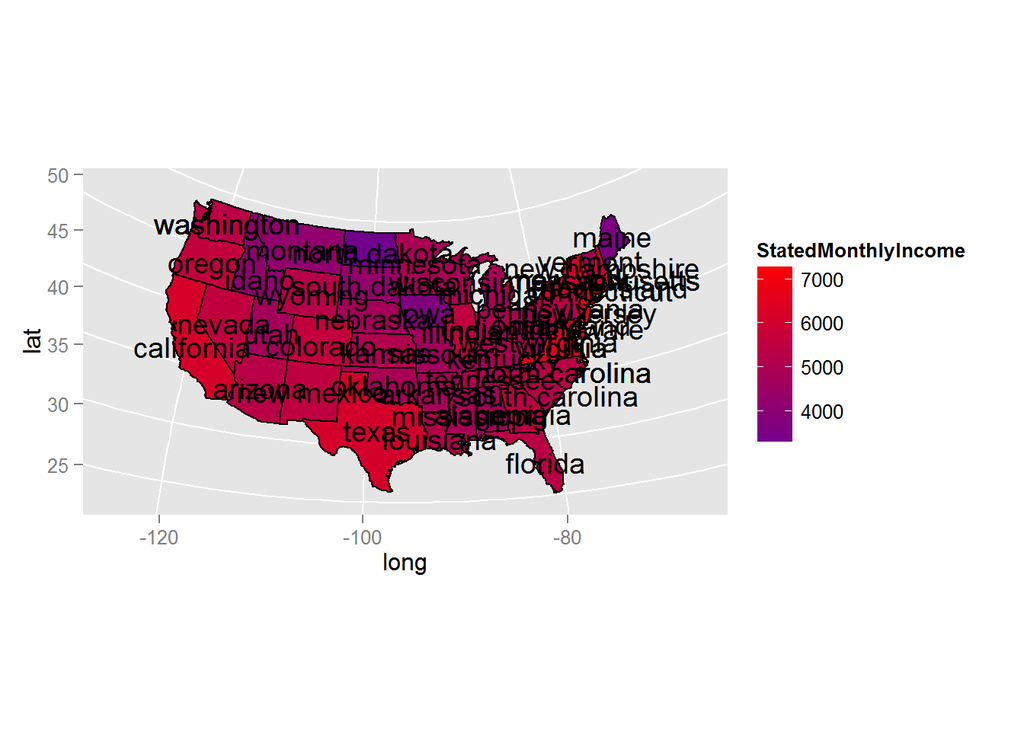

```
##            region StatedMonthlyIncome
## 1     connecticut            7394.697
## 2      new jersey            6807.020
## 3        maryland            6516.032
## 4        virginia            6508.574
## 5        new york            6225.881
## 6   massachusetts            6190.190
## 7      california            6184.829
## 8           texas            6134.473
## 9   new hampshire            5855.356
## 10       delaware            5754.263
## 11         oregon            5662.285
## 12       colorado            5647.536
## 13       illinois            5590.820
## 14         nevada            5589.204
```

[output cut: 34 more lines]

### Description Two

We can see that Connecticut, New Jersey, Maryland, Virginia and New York are the top 5 states with highest mean stated Monthly income. When we compare with the number of loans taken (where the bulk of borrowers live in California, Texas, New York, Florida and Illinois) we do not see there is a 100% correlation between top 5 loans borrowed by state vs top 5 mean statedMonthlyIncome by state. If we check the state population estimate as of 1st July 2014 from wikipedia, we can see that the top 5 states with the biggest population corresponds with the top 5 states with number of loans.

### Plot Three

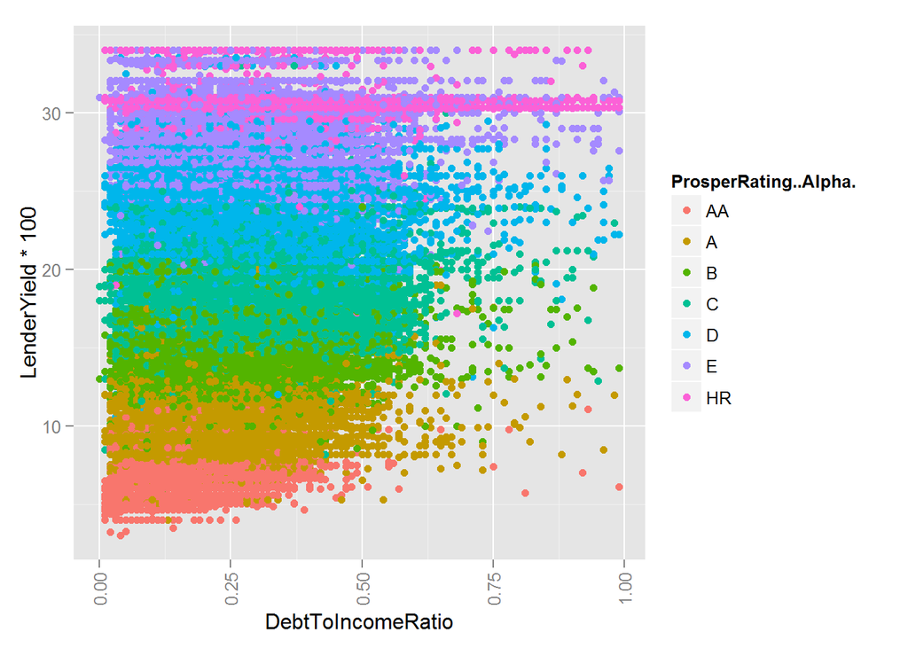

### Description Three

Based on the plot, we can conclude that lower proper rating is associated with higher yield to lender despite the borrower having a low Debt To Income Ratio <= 1.0. We can see that borrower the same proper rating clustered aroung the same ranges of yield.

```r
range(arrange(distinct(subset(ld,ProsperRating..Alpha.=="AA"&DebtToIncomeRatio<1.0,select=c("LenderYield"))),desc(LenderYield)))
```

```
## [1] 0.03 0.20
```

We can see that lender yield ranges from 3% to 20% for Borrowers with propser rating alpha of “AA”" and debt to income ratio below 1.0.

# Reflection

After doing this project that i realize that R is a powerful visualization and statistical computation tool. It is very easy to compute statistics and graphs with the help of libraries like plyr, dylr and ggplot.

Based on the models created we can see that 3 variables prosper score, total prosper loans and propserrating.. alpha has correlation of over 90% with BorrowerRate, Estimated Loss and Lender yield. I feel that, it will be interesting to build a model to determine prosper score to enrich the analysis.

Personally, I feel that Prosper Loans is a viable alternative investment. Based on my analysis of the borrowers with Prosper Rating .. Alpha of “AA” and Debt to income Ratio below 1.0 the lender yield is between 3% to 20% which I feel is an attractive return.

After this project, i feel that i equiped with the necessary knowledge to explore other datasets.

# Reference

- [How To Find Relationship Between Variables, Multiple Regression] (http://www.statsoft.com/textbook/multiple-regression)
- [Prosper - company Overview] (https://www.prosper.com/about)
- [GGplot from yhat] (http://ggplot.yhathq.com/)
- [R Studio - rmarkdown reference](http://www.rstudio.com/wp-content/uploads/2015/03/rmarkdown-reference.pdf)
- [R Graphics Cookbook] (http://www.cookbook-r.com/Graphs/index.html)
- [Wikipedia - List of U.S. states and territories by population](http://en.wikipedia.org/wiki/List_of_U.S._states_and_territories_by_population)